# A Taste of R

R is an interpreted language for analyzing and visualizing data. It’s very different from products like Minitab and JMP even though the users’ goals are often the same. Perhaps the most important factor to the success of R is that it’s free and open source. Because of its accessibility, many people have chosen to adopt it for research, for business purposes, and for teaching. Some of them created packages that would let R do the analysis they needed to do, or as a way to enable people to do a new kind of analysis altogether. R grew and grew. Today it is an indispensable tool for many statisticians and data scientists.

There’s no way to cover most or even much of R and the important packages. Instead, I’ve tried to give a taste of R, enough to get people through the examples contained in the subsequent sections. Each chapter except for this chapter corresponds to the same numbered chapter in *Design and Analysis of Experiments*. This document is very much a companion - on its own it will likely make little to no sense, but used with the textbook it should allow R users to follow along with the examples.

This chapter is divided into two main parts. First, I will describe how to get and install R and associate tools. Second, I will cover how key features of the R language work.

# Getting Started

To get started we will first download the R interpreter so that we can run R code. Then we will download the RStudio editor to make editing nice and easy. Finally we will install the `MontgomeryDAE` package from GitHub to bring in all of the data-sets from the textbook.

## Installing the R Interpreter

At present you can find R through the website https://www.r-project.org. There you can download a version of R best suited for your operating system, and learn what code names each release has (the present release 3.6.1 is *Action of the Toes*).

When reading about R you’ll see CRAN a lot. CRAN standards for Comprehensive R Archive Network and it’s where you’ll actually be downloading R and most packages. Packages are collections of code (in R, C, Fortran, or other languages), data sets, and documentation that we load using the `library` function. There is a *huge* variety of R packages that cover almost anything you could want (note the “almost” qualifier).

Microsoft began seriously investing in R back in 2015 when it acquired Revolution Analytics. Since then they’ve developed their own runtime for R that has improved performance (see https://mran.microsoft.com/open) but often lags behind the current version of CRAN R. Microsoft has integrated R into other products as well - you can run R code directly inside SQL Server queries. I tend to use CRAN R over MRO since that’s the version packages are tested against.

## Install RStudio

Most people use an integrated development environment (IDE) called RStudio (https://www.rstudio.com/) when they work with R. In fact, once you start using RStudio if you ever have to go back to the regular R environment it feels very punishing. A free version of RStudio is available for most operating systems. The RStudio IDE is also extremely useful for publishing via RMarkdown, package development, and a host of other R-related activities.

## R Studio Window

The R Studio window has four main panes. The top left is where you can edit files and highlight code to run. The bottom left is the interactive R session and you can enter commands there directly if you wish. The bottom left also has a terminal tab so that you can use the command prompt or shell from within the application.

[figure not shown]

The top right includes a list of all variables in the global environment and also has a history tab of all commands you’ve run. The bottom right will show files, packages, plots, and help files while you work. RStudio has many more features which I will not cover.

## Packages and Libraries

As I mentioned earlier, packages are collections of code, data, and help files that extend the capabilities of R. Some packages, such as `MASS`, are shipped with R. Others can be downloaded and installed by R using the `install.packages` function (or in R Studio go to Tools > Install Packages). Let’s load the `MASS` package and use `fractions` to convert decimals to their nearest rational expression.

```r
library("MASS")
fractions(0.333333)
# [1] 1/3
```

The `MontgomeryDAE` package contains data files from the textbook as well as a copy of this document. To get this package we need to use `devtools` to install it from GitHub. Installing `devtools` and loading it is simple:

```r
install.packages('devtools')
library('devtools')
```

Then, to install the package from GitHub we use the `install_github` function.

```r
install_github("ehassler/MontgomeryDAE")
```

You can then use the `browseVignettes` function to see documents for the `MontgomeryDAE` package:

```r
browseVignettes(package='MontgomeryDAE')
```

This should open a new window and show entries `chapter01` through `chapter15` in a help window.

# The R Language

If you’ve worked with a C-like language you’ll feel comfortable with R. The way R’s syntax works is something between Javascript and Python. You don’t have to worry about declaring types or compiling your code. Instead you can work with R pretty interactively, typing different things into a session and seeing how things work out. This enables an R user to efficiently do exploratory data analysis while preserving the reproducibility of that exploration (since we can simply re-run that set of commands to get the same results).

Everything in R is an object. You can assign functions to variables and return functions from functions. An odd thing about R is that it has functions to interact with the parse tree of the code that’s currently being evaluated. Sometimes you’ll see R somehow “knows” the name of the variable you passed into a function and uses that as a label on a graph. Don’t be alarmed. R is not becoming self aware.

One example of this oddity is in loading libraries. Previously we loaded the `MASS` package using

```r
library("MASS")
```

but we could have also used

```r
library(MASS)
```

to load it.

R is an interpreted language with an interactive interpreter. Most of the time I work by writing code, highlighting it, then I have RStudio execute it in the interactive session. I’ll then play around with that session to figure out what kind of bugs are occurring or to pull up a help file. R’s help system is very convenient. Once I feel like my analysis is where I want it to be I’ll perform a final check before submitting it to a stake holder: I’ll restart my R environment and run the script I’ve made to make sure the results are what I expect.

To get help with a function or package in R all you have to do is enter a question mark followed by the name. Help files usually include examples as well. Try entering the following:

```r
?cat
```

We can use this function to print to the output.

```r
cat('hello world')
# hello world
```

We could have also used the `print` function.

```r
print("Hello cat!")
# [1] "Hello cat!"
```

We printed the string `'hello world'` and `"Hello cat!"`, each using different quotation. This makes no difference, the objects are the same.

```r
print(class("Hello"))
# [1] "character"
print(class('Hello'))
# [1] "character"
print('Hello' == "Hello")
# [1] TRUE
```

Arithmetic operators work as expected as well. For example, if we wish to raise 12 to the second power and add 1 we simply do:

```r
print(12^2 + 1)
# [1] 145
```

Assignment to a variable can be done a number of ways, but I try to stick to using `<-`. Let’s create a variable and change its value.

```r
friends <- 1
friends <- friends + 1
print(friends)
# [1] 2
```

Here we see that we assigned a value of 1 to `friends`, then we added 1 to it, to end up with 2 friends. User of `=` is also very common. Using that our code would be:

```r
friends = 1
friends = friends + 1
print(friends)
# [1] 2
```

An odd thing about R is that you can use a period in variable names. The identifier `total.weight` is perfectly valid, but one should be careful to note that this *is not* referencing the `weight` property on a `total` object. Instead, it’s pretty much equivalent to `total_weight`. The use of period instead of underscore can be seen lots of places in R because way back in the day underscore was how assignment was performed. It’s not anymore so don’t worry about it.

There are some important constants in R as well. `TRUE` and `FALSE` mean what you’d expect but must be all capitalized, as does `NULL`. R also has `NA` to represent a not-available value. Let’s use the `c` function to concatenate several numbers and then get the median.

```r
x <- c(1, 2.2, 3.2e-1)
print(x)
# [1] 1.00 2.20 0.32
print(median(x))
# [1] 1
```

If we add `NA` into our data then the median would also be not available, so

```r
x <- c(1, 2.2, 3.2e-1, NA)
print(median(x))
# [1] NA
```

However, we can tell median to just ignore `NA` values.

```r
print(median(x, na.rm=TRUE))
# [1] 1
```

Here, I used the name of the argument instead of its position to call the function. This makes calling functions with many arguments that have default values very easy.

## Functions

Let’s create a function to increase our friends. I’ll give the second argument a default value so that, if we leave it out of our function call it will take on that value.

```r
f <- function(friend.count, new.friends=1){
  return(friend.count + new.friends)
}

friends <- 2
print(f(friends, 2))
# [1] 4
print(f(friends))
# [1] 3
print(f(new.friends=1, friend.count=3))
# [1] 4
```

Note that at the end we reversed the order of the arguments, but since we named them everything acts as we would expect.

In R almost all arguments of a function are passed by value - that is to say a copy is made and then thrown away when the function completes. Consider this example:

```r
x <- 1

f <- function(y){
  y <- y + 1
  return(y)
}

print(f(x))
# [1] 2
print(f(x))
# [1] 2
```

One final note about functions. The last thing in a function is returned automatically. In the interactive session the returned value is sent to `print`. Thus we can rewrite our previous function as follows:

```r
x <- 1

f <- function(y){
  y + 1
}

f(x)
# [1] 2
```

## Vectors

Most things in R are stored as vectors of the same type. Usually your vector will be numeric, logical (booleans), characters, or a more general object of some kind. R will coerce values to make sure they are able to be put in the same vector.

```r
c(1, 2, 3, '4')
# [1] "1" "2" "3" "4"
```

Above, R decided that character was the best way to store all of those values together.

```r
c(1, 2, 3, as.numeric('4'))
# [1] 1 2 3 4
```

Here, `as.numeric` converted the string to a number and so the vector remained as numbers.

Instead of writing the whole sequence of numbers from 1 to 4 we could have used R’s shortcut notation:

```r
1:4
# [1] 1 2 3 4
```

For more complicated sequences we can use the `seq` function.

Vectors can also have names for their elements. This is very helpful in displaying data and accessing it.

```r
x <- c('first'=1, 'second'=2, 'third'=3)
x
#  first second  third
#      1      2      3
```

We can then retrieve a specific element either with the numeric offset (starting with 1 for the first element) or by the name

```r
print(x[1])
# first
#     1
print(x['second'])
# second
#      2
```

It’s worth repeating that indexing in R starts with 1. Many programming languages start with 0, and R does not emit an error when you attempt to access the 0th element.

```r
x[0]
# named numeric(0)
```

This is a common source of bugs for in code.

When we compare vectors we get a boolean vector back, and we can use that vector to select elements. Consider the following example of random high temperatures in Phoenix, AZ:

```r
x <- c(102, 82, 93, 118, 117, 89, 84, 74, 114, 115)
index <- x < 100
print(index)
#  [1] FALSE  TRUE  TRUE FALSE FALSE  TRUE  TRUE  TRUE FALSE FALSE
x[index]
# [1] 82 93 89 84 74
```

We can also use an integer vector of offsets to select from a vector:

```r
index <- 1:(length(x)/2)
print(index)
# [1] 1 2 3 4 5
index <- index * 2
print(index)
# [1]  2  4  6  8 10
print(x[index])
# [1]  82 118  89  74 115
```

## Matrices and Arrays

Matrices are essentially two-dimensional vectors, and are a type of array. In R we can define an arbitrary-dimensional vector structure with the `array` function.

```r
X <- matrix(c(1,0,0,0,1,0,0,0,1), ncol=3)
X
#      [,1] [,2] [,3]
# [1,]    1    0    0
# [2,]    0    1    0
# [3,]    0    0    1
```

We can use our fancy indices to access sub-matrices.

```r
X[c(1,2),2]
# [1] 0 1
```

A 3-dimensional array can also easily be constructed.

```r
W <- array(
  c(
    c(2,1,1,1,2,1,1,1,2),
    c(3,1,1,1,3,1,1,1,3),
    c(4,1,1,1,4,1,1,1,4)
  ),
  dim=c(3,3,3)
)
W
# , , 1
#
#      [,1] [,2] [,3]
# [1,]    2    1    1
# [2,]    1    2    1
# [3,]    1    1    2
#
# , , 2
#
#      [,1] [,2] [,3]
# [1,]    3    1    1
# [2,]    1    3    1
# [3,]    1    1    3
#
# , , 3
#
#      [,1] [,2] [,3]
# [1,]    4    1    1
# [2,]    1    4    1
# [3,]    1    1    4
```

We can access elements of an array in the same way.

```r
W[1,1:2,1:2]
#      [,1] [,2]
# [1,]    2    3
# [2,]    1    1
```

Certain operators are expressed between percent symbols. For example, matrix multiplication uses `%*%`.

```r
X <- diag(c(1,2,3))
Y <- matrix(c(0,1,0,1,0,0,0,0,1), ncol=3)
X %*% Y
#      [,1] [,2] [,3]
# [1,]    0    1    0
# [2,]    2    0    0
# [3,]    0    0    3
```

## Lists

Lists are a more loose association of data. A list doesn’t require the types be the same.

```r
y <- list(2, 4, '6', expression(8))
print(y)
# [[1]]
# [1] 2
#
# [[2]]
# [1] 4
#
# [[3]]
# [1] "6"
#
# [[4]]
# expression(8)
```

Note the “key” is given between `[[` and `]]`. This is because we can access an element of a list or we can get a sub-list composed of parts of the original list by using `[` and `]` instead. The following return an element:

```r
print(y[[1]])
# [1] 2
print(y[[2]])
# [1] 4
```

whereas the following return a new list:

```r
print(y[1:2])
# [[1]]
# [1] 2
#
# [[2]]
# [1] 4
print(y[1])
# [[1]]
# [1] 2
```

Lists can have string keys as well:

```r
friends <- list(
  'Caroline'='Phoenix',
  'John'='California',
  'Tommy'='California',
  'Gina'='Iowa',
  'Adam'='Vancouver',
  'Paul'='Tempe',
  'Mollie'='Utah'
)
print(friends)
# $Caroline
# [1] "Phoenix"
#
# $John
# [1] "California"
#
# $Tommy
# [1] "California"
#
# $Gina
# [1] "Iowa"
#
# $Adam
# [1] "Vancouver"
#
# $Paul
# [1] "Tempe"
#
# $Mollie
# [1] "Utah"
print(friends[['Adam']])
# [1] "Vancouver"
print(friends[c('Adam', 'Caroline')])
# $Adam
# [1] "Vancouver"
#
# $Caroline
# [1] "Phoenix"
```

Note that the key was printed using a `$` when we printed this list. This is another way we can access elements of a list.

```r
friends$Paul
# [1] "Tempe"
```

## Data Frames

Data frames are the bread-and-butter data structure of R. A `data.frame` is a collection of column vectors that we’ll use to feed data into our statistical models.

```r
df <- data.frame(
  'time'=c(12.1, 13.3, 13.2, 12.6, 12.8),
  'temp'=c(251, 250, 261, 249, 255)
)
df
#   time temp
# 1 12.1  251
# 2 13.3  250
# 3 13.2  261
# 4 12.6  249
# 5 12.8  255
```

We can access elements of a `data.frame` similar to matrices, for example:

```r
df[,'time']
# [1] 12.1 13.3 13.2 12.6 12.8
```

## Investigating a Variable

Two very useful commands for figuring out what a variable is are `str` and `dput`. The `str` function displays the structure of a variable:

```r
str(df)
# 'data.frame': 5 obs. of  2 variables:
#  $ time: num  12.1 13.3 13.2 12.6 12.8
#  $ temp: num  251 250 261 249 255
```

Here we can see that the `data.frame` has 5 observations in each of the 2 columns. Further, both columns are numeric.

The `dput` function writes an ASCII text representation of the object (i.e. we can paste `dput`’s output into R and be guaranteed to get the same object back).

```r
dput(df)
# structure(list(time = c(12.1, 13.3, 13.2, 12.6, 12.8), temp = c(251,
# 250, 261, 249, 255)), class = "data.frame", row.names = c(NA,
# -5L))
```

We can show their equivalence:

```r
df2 <- structure(list(time = c(12.1, 13.3, 13.2, 12.6, 12.8), temp = c(251,
250, 261, 249, 255)), class = "data.frame", row.names = c(NA,
-5L))
df==df2
#      time temp
# [1,] TRUE TRUE
# [2,] TRUE TRUE
# [3,] TRUE TRUE
# [4,] TRUE TRUE
# [5,] TRUE TRUE
```

You’ll note that `dput` told us that under the hood the `data.frame` is a list, and indeed we can access it like a list:

```r
df$time
# [1] 12.1 13.3 13.2 12.6 12.8
```

## Factors

Sometimes we want to indicate a column of a `data.frame` represents qualitative information. For example, if we had assigned people to groups then group 2 isn’t twice as much a group as group 1. In R we handle this with factors.

```r
factor(c(1,2,3,1,3,2,3,3,2,1,2,2,3))
#  [1] 1 2 3 1 3 2 3 3 2 1 2 2 3
# Levels: 1 2 3
```

Some functions understand that levels represent some qualitative information. Let’s load and plot the canonical Iris data set that descibes 50 of each of three species of iris flower in terms of the petal length and width and the sepal length and width (see https://en.wikipedia.org/wiki/Iris_flower_data_set for more about the data set).

```r
library(datasets)
data(iris)
summary(iris)
#   Sepal.Length    Sepal.Width     Petal.Length    Petal.Width
#  Min.   :4.300   Min.   :2.000   Min.   :1.000   Min.   :0.100
#  1st Qu.:5.100   1st Qu.:2.800   1st Qu.:1.600   1st Qu.:0.300
#  Median :5.800   Median :3.000   Median :4.350   Median :1.300
#  Mean   :5.843   Mean   :3.057   Mean   :3.758   Mean   :1.199
#  3rd Qu.:6.400   3rd Qu.:3.300   3rd Qu.:5.100   3rd Qu.:1.800
#  Max.   :7.900   Max.   :4.400   Max.   :6.900   Max.   :2.500
#        Species
#  setosa    :50
#  versicolor:50
#  virginica :50
#
#
#
```

We see there are 3 kinds of iris. Let’s plot `Petal.Length` in terms of `Species`.

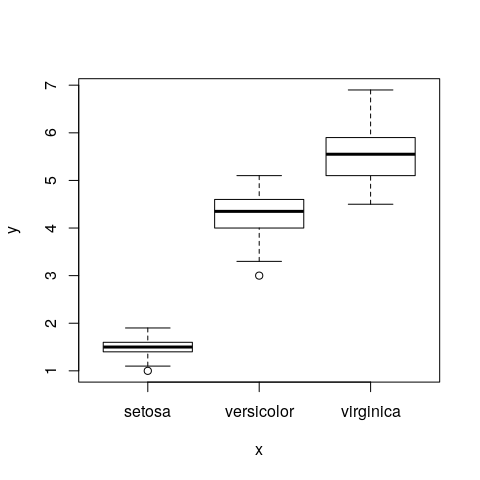

```r
species <- iris[,'Species']
petalLength <- iris[,'Petal.Length']
plot(species, petalLength)
```

R decided that, since we’re using a factor for $x$, a boxplot is most appropriate for showing the data. Now let’s plot `Petal.Length` by `Petal.Width`:

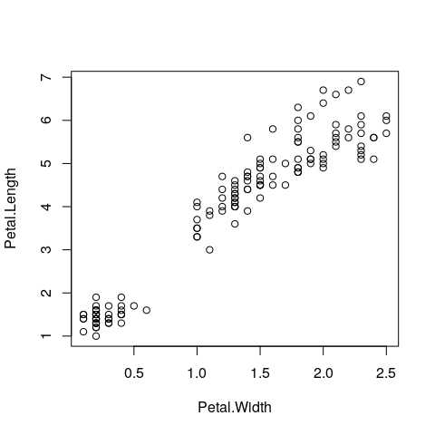

```r
plot(iris[,c('Petal.Width','Petal.Length')])
```

We get a totally different *kind* of plot. This scatter plot relates the petal width to the petal length in a way we’d expect. Let’s go hog-wild!

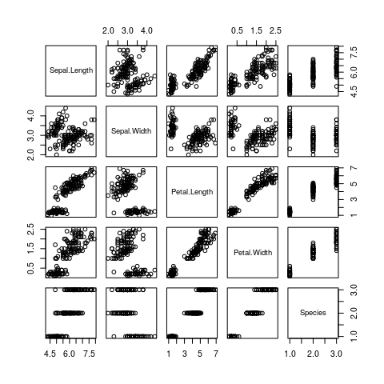

```r
plot(iris)
```

This produces a lattice plot that we can use to see all kinds of 2-way relationships. You may be asking, “Why does `Species` have levels ‘1.0’, ‘2.0’, and ‘3.0’?” Well, those are the indices of the levels of the species factor:

```r
levels(iris$Species)
# [1] "setosa"     "versicolor" "virginica"
```

If we were to convert the factor to numeric we would get back those offsets:

```r
as.numeric(iris$Species)
#   [1] 1 1 1 1 1 1 1 1 1 1 1 1 1 1 1 1 1 1 1 1 1 1 1 1 1 1 1 1 1 1 1 1 1 1 1
#  [36] 1 1 1 1 1 1 1 1 1 1 1 1 1 1 1 2 2 2 2 2 2 2 2 2 2 2 2 2 2 2 2 2 2 2 2
#  [71] 2 2 2 2 2 2 2 2 2 2 2 2 2 2 2 2 2 2 2 2 2 2 2 2 2 2 2 2 2 2 3 3 3 3 3
# [106] 3 3 3 3 3 3 3 3 3 3 3 3 3 3 3 3 3 3 3 3 3 3 3 3 3 3 3 3 3 3 3 3 3 3 3
# [141] 3 3 3 3 3 3 3 3 3 3
```

If we wanted to get the original strings back we could do

```r
as.character(iris$Species)
```

## Formula

An odd about R (the third odd thing for those keeping count) are the formula objects. Let’s say we want to perform a linear regression to predict petal length using petal width and species. R uses something called Wilkinson’s notation to describe this relationship. The following is an example formula relating `Petal.Length` to `Petal.Width` and `Species`.

```r
formula <- Petal.Length ~ Petal.Width + Species
print(class(formula))
# [1] "formula"
print(formula)
# Petal.Length ~ Petal.Width + Species
```

We can use the formula with the `lm` function to get the least squares fit.

```r
lm(Petal.Length ~ Petal.Width + Species, data=iris)
#
# Call:
# lm(formula = Petal.Length ~ Petal.Width + Species, data = iris)
#
# Coefficients:
# (Intercept)  Petal.Width     Species1     Species2
#       2.536        1.019       -1.325        0.373
```

You could also pass a string to `lm` to get the same results

```r
lm("Petal.Length ~ Petal.Width + Species", data=iris)
#
# Call:
# lm(formula = "Petal.Length ~ Petal.Width + Species", data = iris)
#
# Coefficients:
# (Intercept)  Petal.Width     Species1     Species2
#       2.536        1.019       -1.325        0.373
```

The formula also describes how the raw data is to be transformed for modelling. If we used `*` instead of `+` then R would assume we want `Petal.Width`, `Species`, and the two-factor interaction term `Species:Petal.Width`:

```r
lm(Petal.Length ~ Petal.Width * Species, data=iris)
#
# Call:
# lm(formula = Petal.Length ~ Petal.Width * Species, data = iris)
#
# Coefficients:
#          (Intercept)           Petal.Width              Species1
#               2.4498                1.0210               -1.1223
#             Species2  Petal.Width:Species1  Petal.Width:Species2
#              -0.6686               -0.4745                0.8483
```

We can do a lot of fancy things using Wilkinson’s notation and it’s becoming common to see it used in Python (`patsy` package) and Matlab, but I’ll refer you to [a short guide for R from Richard Hahn](https://faculty.chicagobooth.edu/richard.hahn/teaching/formulanotation.pdf) and [Matlab’s documentation](https://www.mathworks.com/help/stats/wilkinson-notation.html) for more information about the notation.

# Where To Learn More

There’s lots of resources to learn more about R.

- [A (Very) Short Introduction to R](https://cran.r-project.org/doc/contrib/Torfs+Brauer-Short-R-Intro.pdf) by Torfs and Braur is an excellent concise introductory PDF.
- The book [R In Action](https://www.manning.com/books/r-in-action) and website [Quick-R](https://www.statmethods.net/) by Rob Kabacoff are also excellent resources.
- DataCamp has a [free introduction to R](https://www.datacamp.com/courses/free-introduction-to-r) course.
- Though much older, the book “Modern Applied Statistics With S-Plus” by Venables and Ripley is a great go-to resource for doing statistical analysis in S. The code almost always works in R.
- The R community and user groups remind me of a friendly data cult: my experience has been of people who are passionate and go out of their way to be helpful to people learning R. Perform a web search to find an R user group or meetup in your area.

# Notes and Problems

- Determining Sample Size - The JMP table in the book seems to want way more samples than what I calculate.
- Smelting Experiment of Section 3.8.3 - I match the variance component point estimates but the CIs are way off from mine.
- Example 11.6 - I can’t get results to match jmp. The rsm package doesn’t do no intercept.
- Chapter 14 - Not sure how to get whole, sub, and residual data… This whole chapter is trouble.